# Prediction of amyloids using n-grams

21-04-2016

## Amyloids

Amyloids are proteins associated with the number of clinical disorders (e.g. Alzheimer's or Creutzfeldt-Jakob's diseases) characterized by the occurence of hot-spots, short (6-15 amino acid) subsequences.

## Hot-spots

- Through hot-spots amyloids can create harmful zipper-like \(\beta\)-structures.
- Hot-spots require not only amino acids with specific physicochemical properties and in specific order.

## Scientific problem

- How to predict amyloids using only amino acid sequences?
- Which patterns of amino acids (**n-grams**) are typical for hot-spots?

## Data source

AmyLoad database (Wozniak and Kotulska, 2015): 397 amyloidogenic and 1033 non-amyloidogenic sequences (1430 in total).

## Encoding of amino acids

We created 524 284 reduced amino acid alphabets (encodings) with different lengths (from three to six letters) using Ward's clusterization on the selected physicochemical properties from AAIndex database.

| Names | Elements |
| --- | --- |
| 1 | G |
| 2 | K, P, R |
| 3 | I, L, V |
| 4 | F, W, Y |
| 5 | A, C, H, M |
| 6 | D, E, N, Q, S, T |

## Encoding of amino acids

Sequence before encoding: YFR  
Sequence after encoding: 442

| Names | Elements |
| --- | --- |
| 1 | G |
| 2 | K, P, R |
| 3 | I, L, V |
| 4 | F, W, Y |
| 5 | A, C, H, M |
| 6 | D, E, N, Q, S, T |

## Prediction of amyloids

Learner associates n-grams from a training set with the status of their source (amyloid/nonamyloid) and uses this information to predict status of peptides from the testing data set.

Sensitivity: recognize amyloids.  
Specificity: recognize nonamyloids.

Both specificity and sensitivity ranges from 0 (completly wrong prediction) to 1 (perfect prediction).

## Prediction of amyloids

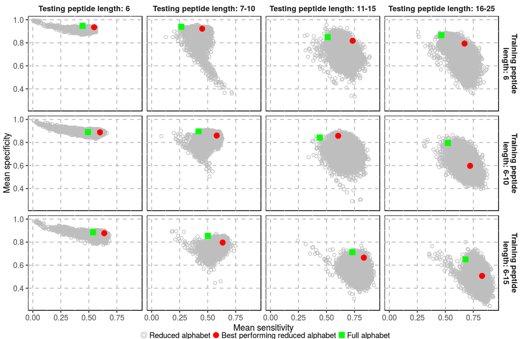

## Encoding distance

Encoding distance measures how much one encoding differs from the other (how many amino acids must be moved between groups to transform the encoding into other one).

AUC defines how well the predictor separates between amyloids and non-amyloids. It ranges from 0 (completly wrong prediction) to 1 (perfect prediction).

## Encoding distance

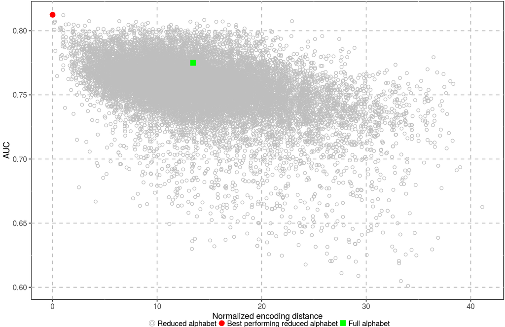

## Encoding distance

The value of AUC is significantly lower for more distant encodings:  
- \(-0.4370\) Pearson's correlation coefficient,  
- p-value smaller than \(2.2 \times 10^{-16}\).

## The best-performing encoding

Two subgroups, 3 and 4 contain strongly hydrophobic amino acids.

Subgroup 1 and 6 have amino acid with the highest average flexibility.

| Names | Elements |
| --- | --- |
| 1 | G |
| 2 | K, P, R |
| 3 | I, L, V |
| 4 | F, W, Y |
| 5 | A, C, H, M |
| 6 | D, E, N, Q, S, T |

## Results - important n-grams

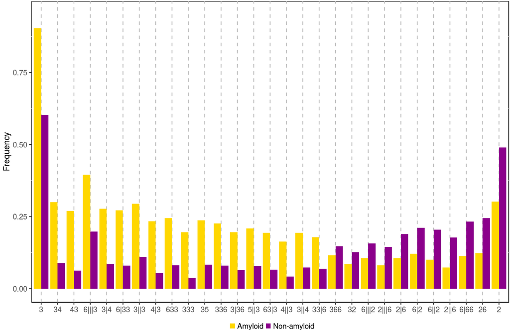

## Results - important n-grams

Amyloids:  
- mostly highly hydrophobic, typical for \(\beta\)-structures amino acids from subgroups 3 and 4.  
- repeats of 3.

Non-amyloids:  
- strongly hydrophilic and highly flexible from subgroups 2 and 6.

## Comparison with other software

| Classifier | AUC | Sensitivity | Specificity |
| --- | --- | --- | --- |
| PASTA2 (Walsh et al., 2014) | 0.854996271439225 | 0.798657718120805 | 0.744444444444444 |
| FoldAmyloid (Garbuzynskiy et al., 2014) | 0.735098185433756 | 0.751677852348993 | 0.718518518518519 |
| AmyloGram | 0.897153865274671 | 0.865771812080537 | 0.788888888888889 |

## Conclusion

The n-gram model of amyloids allows accurate prediction of amyloidogenicity. In addition, it yields interpretable decision rules.

This work was partially funded by by National Science Center (2015/17/N/NZ2/01845). The computations were partially made using the infrastructure provided by Wroclaw Centre for Networking and Supercomputing.